# Portfolio_08

John Lavack 20001249

2026-05-18

```r
knitr::opts_chunk$set(
  echo = TRUE,
  fig.width = 8,
  fig.height = 6,
  fig.align = "center"
)

library(tidyverse)
library(sjPlot)
data <- read.csv("https://R-Resources.massey.ac.nz/161228/PortfolioTasks/Seagrass2649.csv") %>%
  mutate(clarity = as.factor(clarity),
         disturb = as.factor(disturb),
         nitrogen = as.factor(nitrogen))

data %>% head(10)
```

```
##    rep clarity disturb nitrogen seagrass
## 1    1     low     low      low        1
## 2    2     low     low      low        0
## 3    3     low     low      low        1
## 4    4     low     low      low        0
## 5    5     low     low      low        0
## 6    6     low     low      low        1
## 7    7     low     low      low        0
## 8    8     low     low      low        1
## 9    9     low     low      low        1
## 10  10     low     low      low        1
```

# Fit a full model

Looking at the model fit as per the instructions, there are no significant terms. Low clarity is very weakly significant, at 0.1, or 10% alpha error. Above the standard 0.05 P value cut off. From this summary, there are no significant predictors in the data for the prevalence of sea grass meadows.

Note: I do not include the replications variable in the model in order to avoid incorrect inferences from using a glm() model instead of a glmr() model. The latter not covered in class.

```r
model <- glm(seagrass ~ disturb + clarity * nitrogen , data = data, family = binomial(link = 'logit'))

summary(model)
```

```
##
## Call:
## glm(formula = seagrass ~ disturb + clarity * nitrogen, family = binomial(link = "logit"),
##     data = data)
##
## Coefficients:
##                          Estimate Std. Error z value Pr(>|z|)
## (Intercept)            -1.726e-01  5.109e-01  -0.338   0.7354
## disturblow              7.612e-01  4.730e-01   1.609   0.1075
## claritylow             -1.343e+00  6.972e-01  -1.926   0.0541 .
## nitrogenlow            -1.052e-16  6.471e-01   0.000   1.0000
## claritylow:nitrogenlow  1.135e+00  9.497e-01   1.195   0.2321
## ---
## Signif. codes:  0 '***' 0.001 '**' 0.01 '*' 0.05 '.' 0.1 ' ' 1
##
## (Dispersion parameter for binomial family taken to be 1)
##
##     Null deviance: 110.45  on 79  degrees of freedom
## Residual deviance: 102.62  on 75  degrees of freedom
## AIC: 112.62
##
## Number of Fisher Scoring iterations: 4
```

```r
qchisq(0.95, 72)
```

```
## [1] 92.80827
```

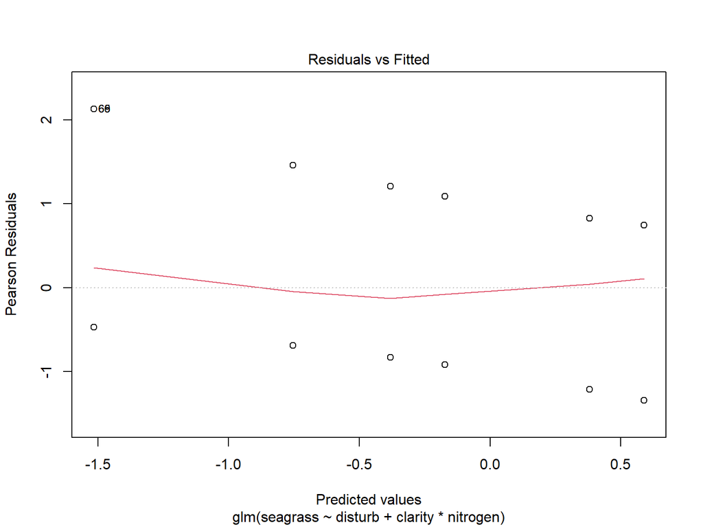

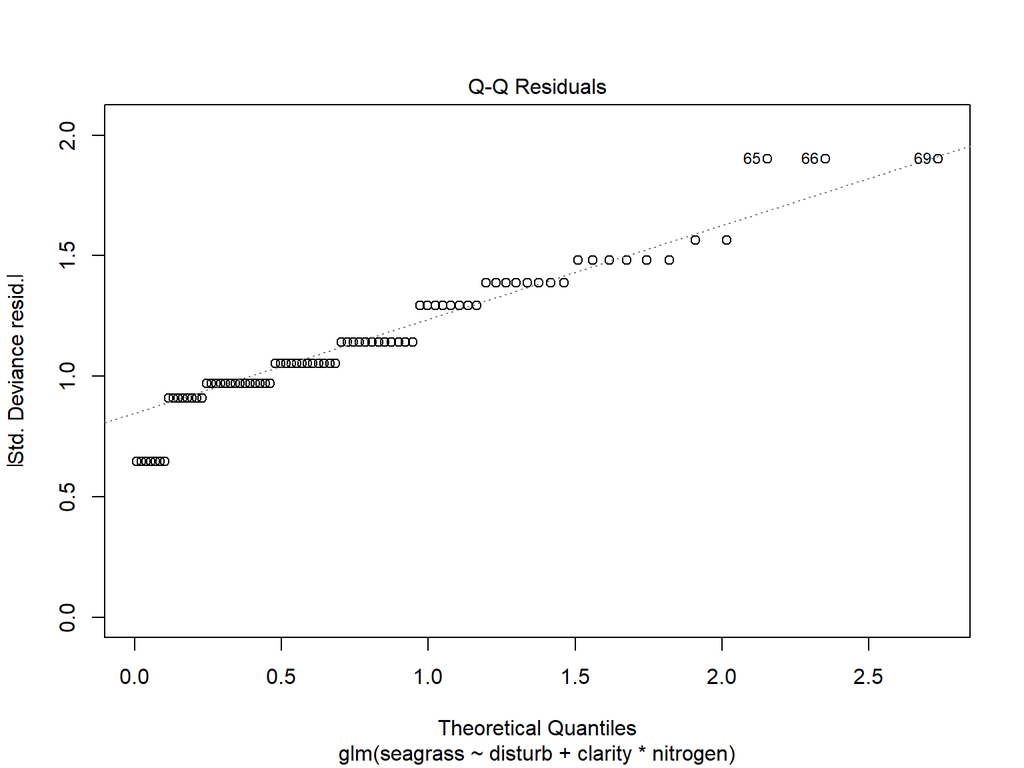

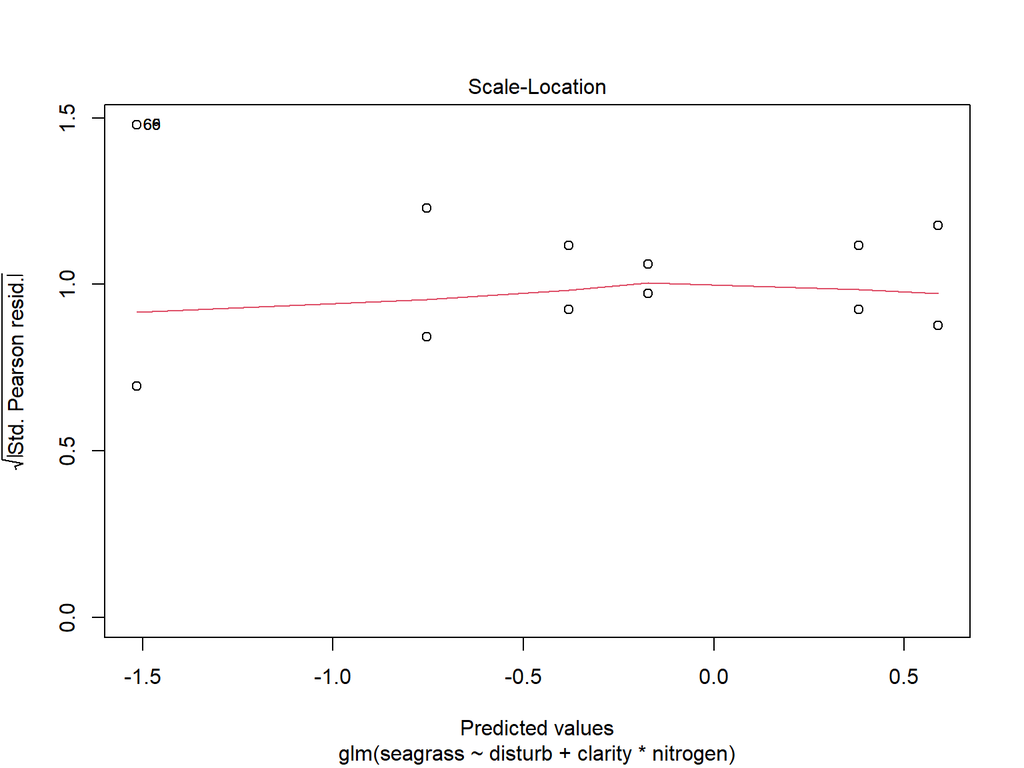

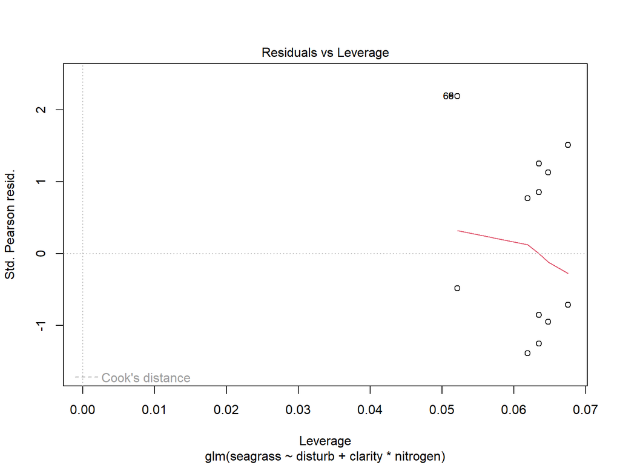

```r
plot(model)
```

# Graph of findings:

```
## Ignoring unknown labels:
## • linetype : "clarity"
## • shape : "clarity"
```

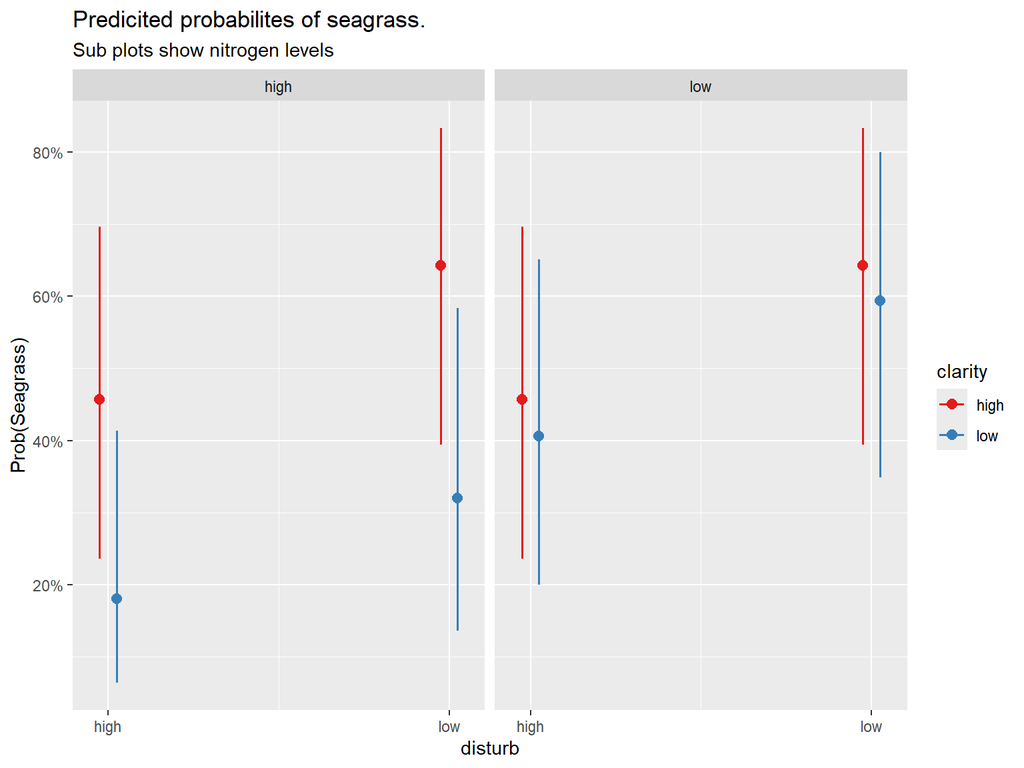

```r
plot_model(model, type = "pred", terms = c('disturb', 'clarity', 'nitrogen'), ci.lvl = 0.95) +
  labs(y = "Prob(Seagrass)",
       title = 'Predicited probabilites of seagrass.',
       subtitle = 'Sub plots show nitrogen levels')
```

# Results description:

The results of the experiment given the data collected about the experimental units are that no factor levels of water clarity, dissolved nitrogen nor physical disturbance has any impact on the presence of seagrass.

This can be seen in the above plot, where in a high dissolved nitrogen environment, under both conditions of disturbance, and clarity, the probability of observing seagrass is not significantly different between factor levels. The 95% confidence intervals in high nitrogen environments overlap at both disturbance levels for clarity; high clarity’s lower 47.5% overlaps with low clarity’s upper 47.5% confidence interval. While at low nitrogen levels the group differences overlap almost completely. Therefore, this experiment has identified that under the conditions chosen, at the factor levels chosen, there is no difference in the presence of seagrass between groups.

High or low water clarity has no impact of seagrass presence.

Dissolved nitrogen at levels 5µmol/L and 20µmol/L have no impact of seagrass presence.

Disturbance in the water by dropping a 5kg weight on the seagrass once a week or once daily has no impact on seagrass.

Nor does the interaction of clarity and nitrogen.